# Statistical model for predicting neonatal weight

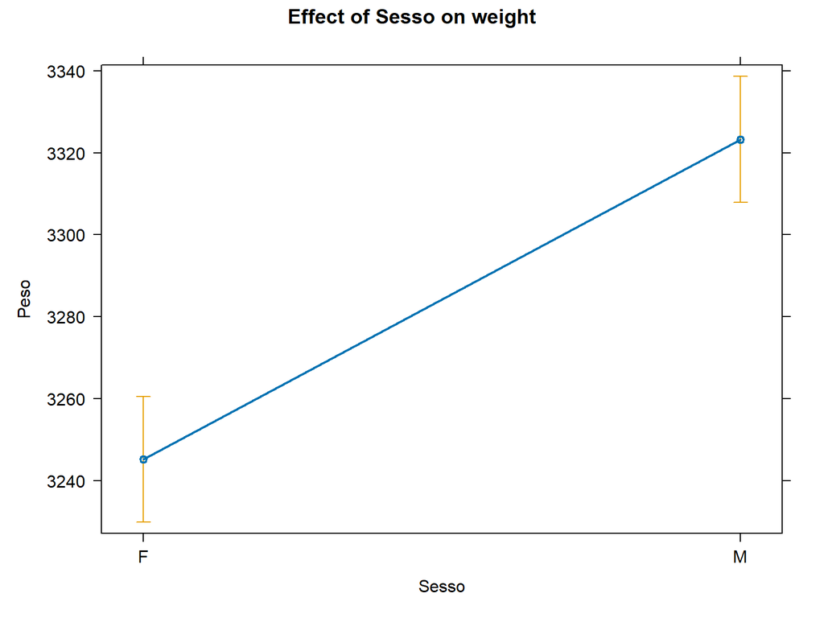

```r
plot(eff, "Sesso", main = "Effect of Sesso on weight")
```

The plots above are intended to show how the dependent variable responds to changes in a single independent variable while holding the other model variables constant. For our Model 3, these plots help identify where the model’s prediction range widens and becomes less precise, and where it remains consistent and reliable.

All variables examined for this model show a positive linear relationship with weight, as previously established. Gestational age, Length, and Head circumference behave similarly: predictions cluster closely around the line when observations are near the mean of the independent variable, yielding more precise, realistic model estimates.

The impact of independent variables becomes less precise as we move away from mean values. This is particularly evident for Gestational age: moving away from the mean of 40 weeks, the model’s possible value range widens considerably around the line, indicating that Gestational age can substantially affect weight predictions.

A more concerning effect is shown by Number of pregnancies: as the count exceeds six, the possible range of predicted weights becomes very broad, so, holding other variables constant it strongly influences predicted weight. This mirrors our earlier analysis, where we hypothesized that the scarcity of data for pregnancies above five makes the distribution’s results imprecise and less reliable.

The sex variable shows how the male-female difference shifts the model’s baseline for predicted weight.

Let’s now plot our observed values against the values predicted by the model.

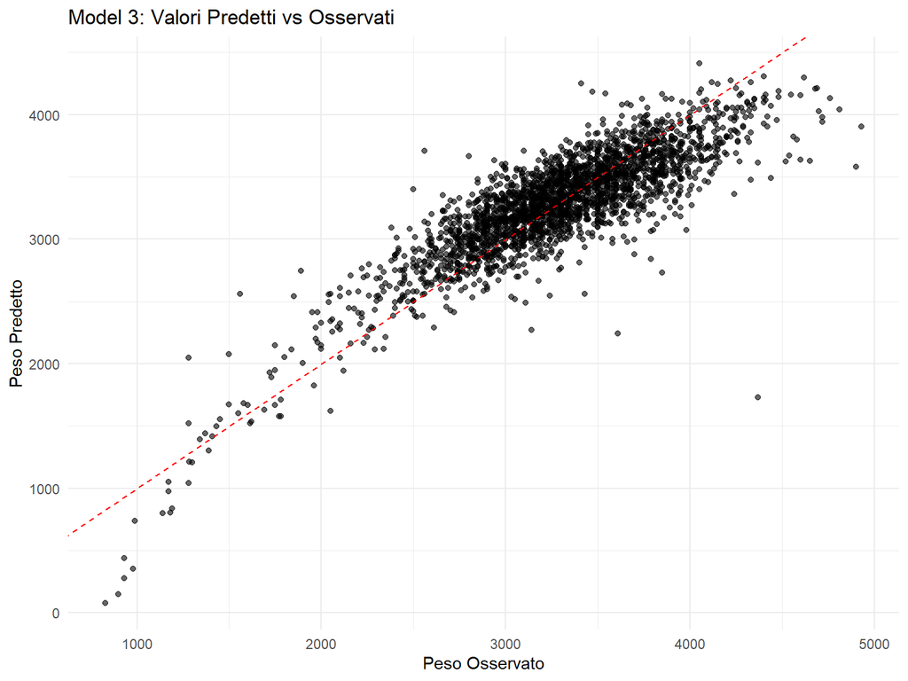

```r
ggplot(data.frame(Observed = neonatalcare_data$Peso, Predicted = fitted(model_3)),
       aes(x = Observed, y = Predicted)) +
  geom_point(alpha = 0.6) +
  geom_abline(intercept = 0, slope = 1, color = "red", linetype = "dashed") +
  labs(title = "Model 3: Valori Predetti vs Osservati", x = "Peso Osservato", y = "Peso Predetto") +
  theme_minimal()
```

The plot is populated with points representing both our dataset observations and the values predicted by Model 3, for the required conditions of the independent variables around that weight value. A precise, reliable model will show points scattered randomly around the red line, without showing non-random curves or specific patterns. Such patterns could indicate a violation of the residual homoscedasticity assumption or the presence of leverage points/outliers.

In this case the model appears precise and reliable for the weight range from 2500g to 4000g, and begins to deviate from the line for values outside this range. In particular deviations are noticeable below 1200g and above 4500g.

Any prediction yielding results below or above these thresholds may therefore be biased by the model and should be considered less reliable than predictions within the central weight range indicated. This effect may be partly explained by the impact of Number of pregnancies and Gestational age on weight, as observed in the earlier partial dependence plots.

## **Final considerations**

The exploration of the dataset provided by Neonatal Health Services yielded several interesting results and suggestions for the company to verify with extended data collection over time.

First we found that the **incidence of maternal smoking** on newborn birth weight is not statistically relevant, at least not with the amount of data available for these two variables. We suspect underreporting in this part of the survey, so we recommend continuing data collection and performing further statistical analyses once more data are available.

We also found no differences in newborn weight across the **three hospitals in the dataset,** and **maternal age and delivery type** do not have any statistically relevant influence on birth weight. By contrast, analyses confirm that male and female newborns show a statistically significant weight difference even when other variables are held equal.

The mother’s **number of previous pregnancies** may influence birth weight to an extent that should not be ignored in the model, particularly from five prior pregnancies onward; however we suspect there are simply too few observations for high parity to assert this with confidence. We therefore invite the company to continue data collection and expand the sample to enable further verification for mothers with many prior births.

Note that **twin births are not mentioned** anywhere in the dataset, so the company may not be able to predict such cases adequately with the selected model. We suspect simultaneous gestation of two fetuses could affect average birth weight and should be included in future data collection.

The variables found to have significant relations with the dependent variable Weight are **gestational age, length and head circumference,** with the latter two being particularly influential. As expected greater gestational age corresponds to higher birth weight; Length and head diameter also increase with gestation, with **no problematic multicollinearity** among the independent variables.

Given these relationships we built a **multiple linear regression prediction model** using these independent variables. Model 3 explains 72.65% of the variability in Weight, achieving **good predictive performance**.

Further checks indicate this model is reliable and usable for newborns whose predicted birth weight falls between 2500g and 4000g; reliability decreases above 4000g and below 1200g. For edge cases outside or near these thresholds, we recommend the company treat individual predictions cautiously and perform additional clinical assessments.

Finally we recommend double-checking newly entered dataset values to avoid typographical or data-entry errors. We detected some problematic values due to entry mistakes. We suggest reviewing the flagged cases together with medical staff.